# Garrido-Sanz & Keel (2025) — RhizCom Propagation Microbiome, Reproduced with Pyloseq

**Reference:** Garrido-Sanz, D., Keel, C. (2025). *RhizCom propagation: microbiome analyses.* Keel Lab, Department of Fundamental Microbiology, University of Lausanne.

The study follows **RhizCom** — a synthetic community assembled from wheat rhizosphere soil — through six serial propagation cycles. Starting from bulk soil (Soil), a washed rhizosphere inoculum (SoilWash) seeds six successive plant-associated growth cycles (Cycle1–Cycle6). A final recovery sample (Recovered) and a strain-bank reference (SbRB) complete the time series. Amplicon sequencing of the 16S rRNA gene (DADA2 pipeline, 40 samples total, 9 904 ASVs) tracks how community structure changes with each propagation.

Key biological questions addressed:

- How does alpha diversity (richness, evenness, phylogenetic diversity) evolve across propagation cycles?
- Do community composition (beta diversity) and phylogenetic structure shift consistently from Soil through the propagation series?
- Which Cycle6 ASVs can be traced back to the original inoculum vs. the strain bank vs. untracked sources?

This notebook reproduces the main phyloseq analyses from `RhizCom_Amplicon_sequence_analyses.Rmd` using Python and `pyloseq`. Each code cell shows the original R call it mirrors. A phylogenetic tree is available, enabling GUniFrac distances and Faith's PD — analyses not possible in datasets without a tree.

| Data file | Contents |
| --- | --- |
| `Taxtable_dada2.txt` | Taxonomy table: 9 904 ASV sequences × 7 ranks (Kingdom → Species) |
| `ASV_sequences.txt` | OTU table: 40 samples × 9 904 ASV sequences (raw counts) |
| `metadata.txt` | Sample metadata: group name, propagation order, replicate, RGB color |
| `seqtab.nochim_aln.fasta.treefile` | IQ-TREE phylogeny (unrooted Newick); tips are 1-based integer indices |

| R call | pyloseq equivalent |
| --- | --- |
| `otu_table(seqtab.nochim2, taxa_are_rows=FALSE)` | `OtuTable(asv_df, taxa_are_rows=False)` |
| `taxa_names(ps) = paste0("ASV", seq(ntaxa(ps)))` | rename index/columns before building |
| `subset_taxa(ps, Genus!="Mitochondria")` | `subset_taxa(ps, lambda t: t["Genus"] != "Mitochondria")` |
| `prune_taxa(prev0 > threshold, ps)` | `prune_taxa(keep_list, ps)` |
| `GUniFrac(otu.tab, phy_tree, alpha=c(0,0.5,1))` | `gunifrac(ps, alpha=(0, 0.5, 1))` |
| `ordinate(ps, method="PCoA", distance=dist)` | `ordinate(ps, method="PCoA", distance=dist)` |

### Setup

```python
import warnings

import matplotlib.patches as mpatches
import matplotlib.pyplot as plt
import numpy as np
import pandas as pd
import seaborn as sns
import skbio.tree
from scipy.stats import kruskal, spearmanr

from pyloseq import (
    OtuTable,
    Phyloseq,
    PhyTree,
    SampleData,
    TaxTable,
    estimate_richness,
    gunifrac,
    merge_samples,
    ordinate,
    permanova,
    prune_taxa,
    psmelt,
    subset_taxa,
    tax_glom,
    transform_sample_counts,
)
from pyloseq import (
    distance as pldistance,
)

warnings.filterwarnings("ignore")

DATA = "data/garridosanz"
RNG = np.random.default_rng(42)
```

### 1. Load Data & Build the Phyloseq Object

Three text files (semicolon- or tab-delimited) plus one Newick tree:

| File | R read call | pandas equivalent |
| --- | --- | --- |
| `Taxtable_dada2.txt` | `read.table(..., sep=";")` | `pd.read_csv(..., sep=";", index_col=0)` |
| `ASV_sequences.txt` | `fread(..., sep=";")` | `pd.read_csv(..., sep=";", index_col=0)` |
| `metadata.txt` | `read.table(..., sep="\t")` | `pd.read_csv(..., sep="\t", index_col="id_samples")` |
| `seqtab.nochim_aln.fasta.treefile` | `read.tree(...)` | `PhyTree.from_newick_file(...)` |

**Tree tip label remapping.** IQ-TREE labels tips with 1-based integer indices (e.g. `"1"`, `"44"`, `"402"`) corresponding to the row order of the taxa table. R phyloseq renames these to sequences via:

```
index = rownames_to_column(data.frame(seqs=rownames(taxa2)), "index")
tip_tax = left_join(data.frame(index=tree$tip.label), index)
tree$tip.label = tip_tax$seqs
```

We build the same integer → `ASV{n}` map, rename tree tips before constructing the phyloseq object, and avoid loading the full sequence strings as identifiers throughout.

**ASV renaming.** R then renames all taxa names to `ASV1`, `ASV2`, … via `paste0("ASV", seq(ntaxa(ps)))`. We apply this renaming to the taxonomy table, OTU table columns, and tree tip labels upfront.

```python
# R: taxa2 = read.table("Taxtable_dada2.txt", sep=";", header=T)
#    taxa2 = column_to_rownames(taxa2, "X")
tax_raw = pd.read_csv(f"{DATA}/Taxtable_dada2.txt", sep=";", index_col=0)
if "Species.1" in tax_raw.columns:
    tax_raw = tax_raw.drop(columns=["Species.1"])

# R: seqtab.nochim2 = fread("ASV_sequences.txt", sep=";", header=T)
#    rownames(seqtab.nochim2) = gsub("_$", "", rownames(seqtab.nochim2))
asv_raw = pd.read_csv(f"{DATA}/ASV_sequences.txt", sep=";", index_col=0)
asv_raw.index = asv_raw.index.str.rstrip("_")

# R: metadata = read.table("metadata.txt", header=T, sep="\t")
#    rownames(metadata) = metadata$id_samples
metadata = pd.read_csv(f"{DATA}/metadata.txt", sep="\t", index_col="id_samples")
# Strip surrounding quotes from RGBcol
metadata["RGBcol"] = metadata["RGBcol"].str.strip('"')

print(f"Raw ASV table:  {asv_raw.shape[0]} samples × {asv_raw.shape[1]} ASVs")
print(f"Taxonomy table: {tax_raw.shape[0]} ASVs × {tax_raw.shape[1]} ranks ({list(tax_raw.columns)})")
print(f"Metadata:       {metadata.shape[0]} samples × {metadata.shape[1]} variables")
print(f"Groups:         {sorted(metadata['Name'].unique())}")
```

```
Raw ASV table:  40 samples × 9904 ASVs
Taxonomy table: 9904 ASVs × 7 ranks (['Kingdom', 'Phylum', 'Class', 'Order', 'Family', 'Genus', 'Species'])
Metadata:       40 samples × 6 variables
Groups:         ['Cycle1', 'Cycle2', 'Cycle3', 'Cycle4', 'Cycle5', 'Cycle6', 'Recovered', 'SbRB', 'Soil', 'SoilWash']
```

```python
# R: taxa_names(ps) = paste0("ASV", seq(ntaxa(ps)))
# Build renaming maps upfront so OTU table, tax table, and tree all share ASV{n} names.
n_asvs = len(tax_raw)
asv_names  = {seq: f"ASV{i+1}" for i, seq in enumerate(tax_raw.index)}   # seq  → ASVn
num_to_asv = {str(i+1): f"ASV{i+1}" for i in range(n_asvs)}              # "n" → ASVn (tree tips)

# Apply to taxonomy table
tax_df = tax_raw.copy()
tax_df.index = [f"ASV{i+1}" for i in range(n_asvs)]

# Apply to OTU table columns (sequences → ASVn)
asv_df = asv_raw.rename(columns=asv_names)

# R: tree = read.tree("seqtab.nochim_aln.fasta.treefile")
#    tip_tax = left_join(...) ; tree$tip.label = tip_tax$seqs
tree_node = skbio.tree.TreeNode.read(
    f"{DATA}/seqtab.nochim_aln.fasta.treefile",
    format="newick", convert_underscores=False,
)
for tip in tree_node.tips():
    if tip.name in num_to_asv:
        tip.name = num_to_asv[tip.name]
phy = PhyTree(tree_node)
print(f"Tree: {phy.n_tips} tips, {'rooted' if phy.is_rooted else 'unrooted'}")

# R: ps = phyloseq(otu_table(seqtab.nochim2, taxa_are_rows=FALSE),
#                  sample_data(metadata), tax_table(taxa2), phy_tree(tree))
ps = Phyloseq(
    otu=OtuTable(asv_df, taxa_are_rows=False),
    sam=SampleData(metadata),
    tax=TaxTable(tax_df),
    tree=phy,
)

sums = ps.sample_sums()
print(f"\nPhyloseq object: {ps.ntaxa} taxa × {ps.nsamples} samples")
print(f"  Ranks:     {ps.rank_names}")
print(f"  Variables: {ps.sample_variables}")
print(f"  Tree:      {ps.phy_tree.n_tips} tips")
print(f"\nSequencing depth:  median={sums.median():.0f}  min={sums.min()}  max={sums.max()}")
```

```
Tree: 9904 tips, unrooted

Phyloseq object: 9904 taxa × 40 samples
  Ranks:     ['Kingdom', 'Phylum', 'Class', 'Order', 'Family', 'Genus', 'Species']
  Variables: ['Name', 'Order', 'Order2', 'Replicate', 'Names_rep', 'RGBcol']
  Tree:      9904 tips

Sequencing depth:  median=134970  min=50436  max=214610
```

### 2. Filter

Three filtering steps mirror the R script:

| R call | pyloseq equivalent |
| --- | --- |
| `subset_taxa(ps, Genus!="Mitochondria")` | `subset_taxa(ps, lambda t: t["Genus"] != "Mitochondria")` |
| `prune_taxa(prev0 > prevalenceThreshold, ps)` | `prune_taxa(keep_list, ps)` |
| `subset_taxa(ps1, Phylum %in% names(keepPhyla))` | `prune_taxa(keep_taxa, ps)` |

```python
# R: ps = subset_taxa(ps, Genus!="Mitochondria")
#    ps = subset_taxa(ps, Genus!="Chloroplast")
ps_f = subset_taxa(ps, lambda t: pd.isna(t["Genus"]) or t["Genus"] != "Mitochondria")
ps_f = subset_taxa(ps_f, lambda t: pd.isna(t["Genus"]) or t["Genus"] != "Chloroplast")
print(f"After Mitochondria/Chloroplast removal: {ps_f.ntaxa} ASVs ({ps.ntaxa - ps_f.ntaxa} removed)")

# R: prev0 = apply(otu_table(ps), MARGIN=1, FUN=function(x){sum(x > 0)})
#    prevalenceThreshold = 0.01 * nsamples(ps)
#    ps1 = prune_taxa(prev0 > prevalenceThreshold, ps)
prev_threshold = 0.01 * ps_f.nsamples
otu_for_prev = ps_f.otu_table.to_dataframe()
if not ps_f.otu_table.taxa_are_rows:
    otu_for_prev = otu_for_prev.T  # taxa × samples
prevalence = (otu_for_prev > 0).sum(axis=1)
keep_prev = prevalence[prevalence > prev_threshold].index.tolist()
ps1 = prune_taxa(keep_prev, ps_f)
print(f"Prevalence threshold (>{prev_threshold:.2f} samples): {ps1.ntaxa} ASVs remain")

# R: ps2 = subset_taxa(ps1, Phylum %in% names(keepPhyla))
#    (keepPhyla = phyla with at least one ASV in ps1)
tax_frame = ps1.tax_table.to_frame()
keep_phyla = tax_frame["Phylum"].dropna().unique().tolist()
ps2 = subset_taxa(ps1, lambda t: t["Phylum"] in keep_phyla)

print(f"After unidentified Phylum removal:       {ps2.ntaxa} ASVs")
print(f"Total removed: {ps.ntaxa - ps2.ntaxa} of {ps.ntaxa} raw ASVs ({(ps.ntaxa - ps2.ntaxa)/ps.ntaxa*100:.1f}%)")
print(f"\nPhyla present ({len(keep_phyla)}): {sorted(keep_phyla[:8])} ...")
```

```
After Mitochondria/Chloroplast removal: 9904 ASVs (0 removed)
Prevalence threshold (>0.40 samples): 9904 ASVs remain
After unidentified Phylum removal:       9758 ASVs
Total removed: 146 of 9904 raw ASVs (1.5%)

Phyla present (35): ['Actinobacteriota', 'Armatimonadota', 'Bacteroidota', 'Bdellovibrionota', 'Cyanobacteria', 'Firmicutes', 'Proteobacteria', 'Verrucomicrobiota'] ...
```

### 3. Rarefaction Curves

Rarefaction curves assess sequencing saturation — a plateau indicates that most diversity has been captured at the achieved depth. Samples are colored by propagation group (Soil → Cycle1–6 → Recovered → SbRB).

| R call | Python equivalent |
| --- | --- |
| `ggrare(ps2, step=500, color="Name", se=T)` | Random subsampling + matplotlib |

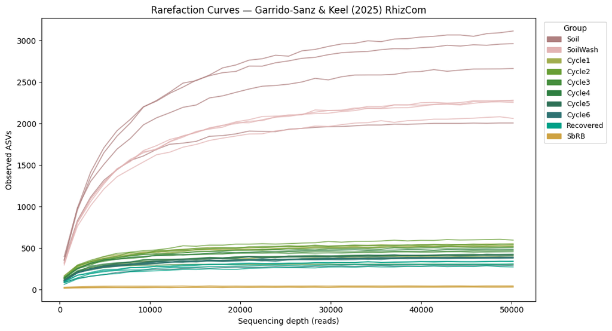

```
Minimum sequencing depth across 40 samples: 50157
```

```python
# Plotting palette and group order from metadata
name_order = (
    metadata.drop_duplicates("Name")
    .sort_values("Order")["Name"]
    .tolist()
)
name_colors = (
    metadata.drop_duplicates("Name")
    .set_index("Name")["RGBcol"]
    .to_dict()
)

otu_taxa_rows = ps2.otu_table.to_dataframe()
if not ps2.otu_table.taxa_are_rows:
    otu_taxa_rows = otu_taxa_rows.T  # taxa × samples

min_depth = int(ps2.sample_sums().min())
depths = np.linspace(500, min_depth, 35, dtype=int)


def rarefaction_curve(counts_int, depths, rng):
    total = counts_int.sum()
    taxa_pool = np.repeat(np.arange(len(counts_int)), counts_int)
    results = []
    for d in depths:
        if d > total:
            break
        samp = rng.choice(taxa_pool, size=d, replace=False)
        results.append((d, len(np.unique(samp))))
    return np.array(results)


fig, ax = plt.subplots(figsize=(11, 6))
for sample in ps2.sample_names:
    cnts = otu_taxa_rows[sample].values.astype(int)
    name = metadata.loc[sample, "Name"]
    curve = rarefaction_curve(cnts, depths, RNG)
    if len(curve):
        ax.plot(curve[:, 0], curve[:, 1], color=name_colors.get(name, "grey"),
                alpha=0.75, linewidth=1.3)

handles = [mpatches.Patch(color=name_colors[n], label=n)
           for n in name_order if n in name_colors]
ax.legend(handles=handles, title="Group", bbox_to_anchor=(1.01, 1),
          loc="upper left", fontsize=9)
ax.set_xlabel("Sequencing depth (reads)")
ax.set_ylabel("Observed ASVs")
ax.set_title("Rarefaction Curves — Garrido-Sanz & Keel (2025) RhizCom")
plt.tight_layout()
plt.show()
print(f"Minimum sequencing depth across {ps2.nsamples} samples: {min_depth}")
```

### 4. Class-Level Taxonomic Composition

Relative abundance bar plots at **Class** level reproduce R's stacked bar charts (`geom_bar(stat="identity", position="stack")` faceted by group). ASVs are first aggregated with `tax_glom(ps2, "Class")` and then normalized to relative abundance per sample. Only the 15 most abundant classes are labeled; remaining classes are collapsed into "Other".

| R call | pyloseq equivalent |
| --- | --- |
| `tax_glom(ps2, taxrank="Class")` | `tax_glom(ps2, "Class")` |
| `transform_sample_counts(ps2, function(x) x/sum(x)*100)` | `transform_sample_counts(ps2_class, lambda x: x/x.sum()*100)` |
| `ggplot(..., aes(fill=Class)) + facet_wrap(~Name, scales="free_x")` | plotnine equivalent |

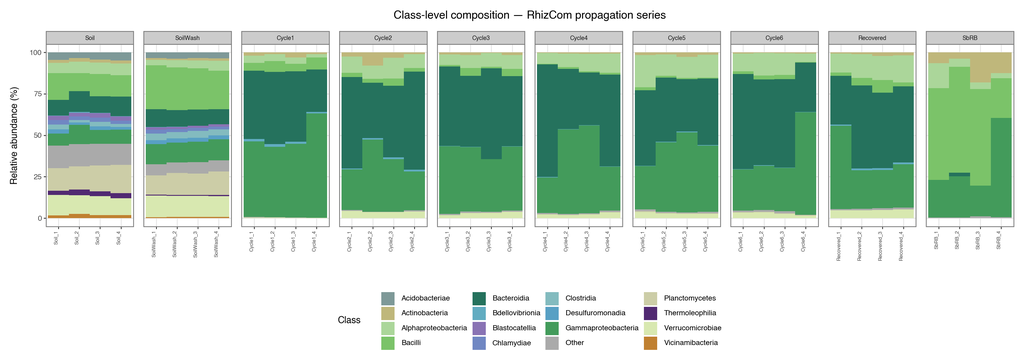

```python
from plotnine import (
    aes,
    element_text,
    facet_wrap,
    geom_bar,
    ggplot,
    ggtitle,
    labs,
    scale_fill_manual,
    theme,
    theme_bw,
)

# R: Class_glom = tax_glom(ps2.css.prop, taxrank="Class")
ps2_class = tax_glom(ps2, "Class")
ps2_rel = transform_sample_counts(ps2_class, lambda x: x / x.sum() * 100)

# psmelt joins both sample_data and tax_table. "Order" appears in both (propagation order
# vs. taxonomic rank), so psmelt suffixes them _x/_y. Map sample-level order directly from
# metadata to avoid the collision.
melted = psmelt(ps2_rel)
melted["_sample_order"] = melted["Sample"].map(metadata["Order"])

# Identify top 15 classes and collapse rest
top_classes = (
    melted.groupby("Class", observed=True)["Abundance"]
    .mean().sort_values(ascending=False).head(15).index.tolist()
)
melted["Class_plot"] = melted["Class"].where(melted["Class"].isin(top_classes), "Other")

# Ordered sample x-axis and facet grouping
sample_order = (
    melted.sort_values(["_sample_order", "Sample"])["Names_rep"]
    .drop_duplicates().tolist()
)
melted["Names_rep"] = pd.Categorical(melted["Names_rep"], categories=sample_order, ordered=True)
melted["Name"] = pd.Categorical(melted["Name"], categories=name_order, ordered=True)

class_palette = [
    "#25725d", "#439b5b", "#7bc369", "#abd69a", "#d8e8b0",
    "#cccda7", "#bfb77b", "#7e9998", "#83bbbf", "#61acc1",
    "#58a0c4", "#7087c3", "#8973b4", "#512972", "#c08030", "#aaaaaa",
]
class_color_map = dict(zip(top_classes + ["Other"], class_palette[:len(top_classes) + 1]))

p = (
    ggplot(melted, aes(x="Names_rep", y="Abundance", fill="Class_plot"))
    + geom_bar(stat="identity", position="stack", width=1)
    + facet_wrap("~Name", scales="free_x", nrow=1)
    + scale_fill_manual(values=class_color_map)
    + labs(x="", y="Relative abundance (%)", fill="Class")
    + ggtitle("Class-level composition — RhizCom propagation series")
    + theme_bw()
    + theme(
        axis_text_x=element_text(angle=90, vjust=0.5, hjust=1, size=6),
        strip_text=element_text(size=7),
        legend_position="bottom",
        figure_size=(17, 6),
    )
)
p
```

### 5. Alpha Diversity

Four alpha diversity metrics are computed for each of the 40 samples:

| Metric | R call | Python call |
| --- | --- | --- |
| Observed ASVs | `plot_richness(ps2, measures="Observed")` | `estimate_richness(ps2, measures=["Observed"])` |
| Shannon index | `plot_richness(ps2, measures="Shannon")` | `estimate_richness(ps2, measures=["Shannon"])` |
| Simpson index | `plot_richness(ps2, measures="Simpson")` | `estimate_richness(ps2, measures=["Simpson"])` |
| Faith's PD | `picante::pd(otu_table(ps2), phy_tree(ps2))` | `skbio.diversity.alpha_diversity("faith_pd", ...)` |

**Faith's PD requires a rooted tree.** The IQ-TREE output is unrooted; we midpoint-root it (equivalent to `phangorn::midpoint(phy_tree(ps))` used elsewhere in the R script).

**Statistical testing.** R uses `agricolae::kruskal` (Kruskal-Wallis + FDR post-hoc). We use `scipy.stats.kruskal` for the omnibus test across all 10 groups.

```python
# Observed, Shannon, Simpson
# R: plot_richness(ps2, x="Name", measures=c("Observed","Shannon","Simpson"))
richness = estimate_richness(ps2, measures=["Observed", "Shannon", "Simpson"])
richness.index.name = "id_samples"
# Join Name and propagation Order from metadata (rename to avoid "Order" taxonomy collision)
richness = richness.join(metadata[["Name"]].rename_axis("id_samples"))
richness["group_order"] = richness.index.map(metadata["Order"])

# Faith's PD — estimate_richness midpoint-roots the tree internally
# R: pd = pd(otu_table(ps2), phy_tree(ps2), include.root=FALSE)
pd_df = estimate_richness(ps2, measures=["PD"])
richness["FaithPD"] = pd_df["PD"]

# Build ps2_rooted for GUniFrac (next section)
rooted_node = ps2.phy_tree._tree.root_at_midpoint()
ps2_rooted = Phyloseq(
    otu=ps2.otu_table,
    sam=ps2.sample_data,
    tax=ps2.tax_table,
    tree=PhyTree(rooted_node),
)

print("Alpha diversity (mean ± SD per group):")
print(
    richness.groupby("Name")[["Observed", "Shannon", "Simpson", "FaithPD"]]
    .agg(["mean", "std"])
    .round(2)
    .to_string()
)
```

```
Alpha diversity (mean ± SD per group):
          Observed         Shannon       Simpson       FaithPD
              mean     std    mean   std    mean   std    mean    std
Name
Cycle1      514.50   67.23    4.40  0.22    0.96  0.00   46.98   5.72
Cycle2      569.25   41.89    4.39  0.16    0.95  0.01   52.92   2.20
Cycle3      441.50   92.82    4.41  0.07    0.96  0.00   47.29   5.44
Cycle4      440.50   40.74    3.88  0.19    0.91  0.03   53.02   3.23
Cycle5      414.50   19.19    4.00  0.09    0.94  0.00   53.37   2.25
Cycle6      370.25   47.70    3.42  0.31    0.86  0.02   50.96   3.18
Recovered   327.75   30.49    3.64  0.24    0.93  0.02   48.15   2.64
SbRB         37.00    6.16    2.15  0.24    0.81  0.04   11.24   1.57
Soil       2719.25  515.10    7.00  0.19    1.00  0.00  337.22  43.71
SoilWash   2287.25  108.34    6.59  0.05    1.00  0.00  275.69   7.76
```

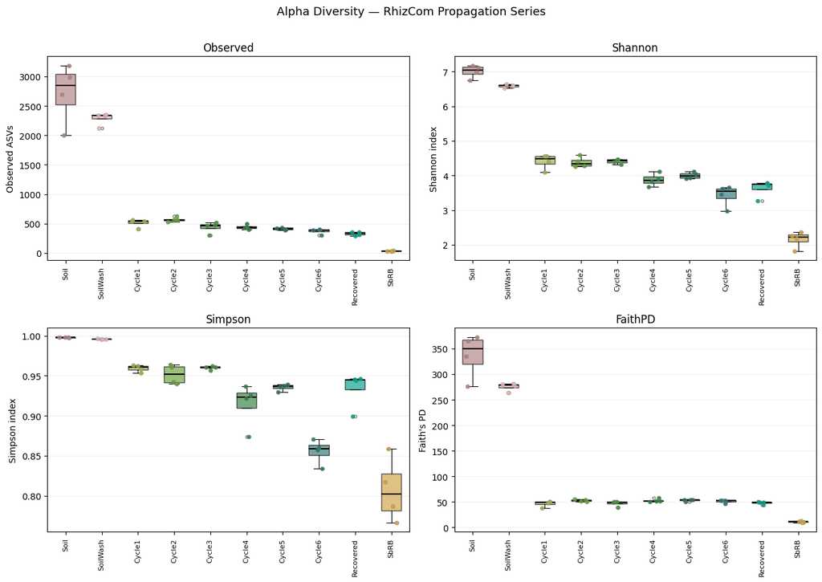

```
Kruskal-Wallis test across all 10 groups:
  Observed    : H =  35.26,  p = 0.0001  ***
  Shannon     : H =  36.87,  p = 0.0000  ***
  Simpson     : H =  36.49,  p = 0.0000  ***
  FaithPD     : H =  32.39,  p = 0.0002  ***
```

```python
# Plot: 2×2 boxplots, one panel per metric
fig, axes = plt.subplots(2, 2, figsize=(13, 9))
measures_plot = [
    ("Observed", "Observed ASVs"),
    ("Shannon",  "Shannon index"),
    ("Simpson",  "Simpson index"),
    ("FaithPD",  "Faith's PD"),
]

for ax, (col, ylabel) in zip(axes.flat, measures_plot):
    for xi, name in enumerate(name_order):
        group = richness[richness["Name"] == name]
        y = group[col].dropna().values
        color = name_colors.get(name, "grey")
        bp = ax.boxplot(
            y, positions=[xi], widths=0.55, patch_artist=True,
            boxprops=dict(facecolor=color, alpha=0.65),
            medianprops=dict(color="black", linewidth=1.5),
            whiskerprops=dict(linewidth=0.8),
            capprops=dict(linewidth=0.8),
            flierprops=dict(marker="o", markersize=3, alpha=0.5),
        )
        jitter = RNG.uniform(-0.18, 0.18, len(y))
        ax.scatter(xi + jitter, y, color=color, s=22, zorder=3, alpha=0.9, edgecolors="grey", linewidths=0.3)

    ax.set_xticks(range(len(name_order)))
    ax.set_xticklabels(name_order, rotation=90, fontsize=8)
    ax.set_ylabel(ylabel)
    ax.set_title(col)
    ax.grid(axis="y", alpha=0.3, linewidth=0.5)

plt.suptitle("Alpha Diversity — RhizCom Propagation Series", y=1.01, fontsize=13)
plt.tight_layout()
plt.show()

# Kruskal-Wallis omnibus test across all groups
# R: kruskal(diver_filt$value, diver_filt$Name, alpha=0.05, p.adj="fdr")
print("Kruskal-Wallis test across all 10 groups:")
for col, _ in measures_plot:
    groups = [richness.loc[richness["Name"] == n, col].dropna().values for n in name_order]
    stat, p = kruskal(*groups)
    sig = "***" if p < 0.001 else "**" if p < 0.01 else "*" if p < 0.05 else "ns"
    print(f"  {col:<12}: H = {stat:6.2f},  p = {p:.4f}  {sig}")
```

### 6. Alpha Diversity Correlation with Propagation Cycle

For the six cycle samples (Cycle1–Cycle6), does diversity change monotonically with propagation number? Spearman correlation tests for a rank-order trend between cycle number and each diversity metric.

| R call | Python equivalent |
| --- | --- |
| `diver.ob.good = filter(diver.ob$data, grepl("Cycle", Name))` | `richness[richness["Name"].str.startswith("Cycle")]` |
| `stat_cor(method="spearman")` | `scipy.stats.spearmanr` |

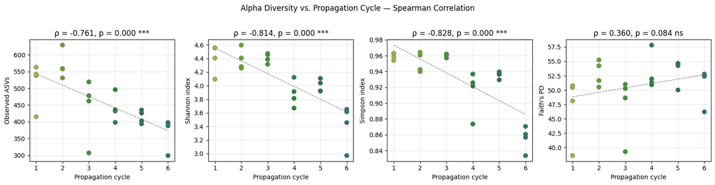

```python
# R: diver.ob.good = filter(diver.ob$data, grepl("Cycle", Name))
#    stat_cor(method="spearman")
cycles = richness[richness["Name"].str.startswith("Cycle")].copy()
cycles["CycleNum"] = cycles["Name"].str.replace("Cycle", "").astype(int)

fig, axes = plt.subplots(1, 4, figsize=(16, 4))
for ax, (col, ylabel) in zip(axes, measures_plot):
    x = cycles["CycleNum"].values
    y = cycles[col].values
    rho, p = spearmanr(x, y)

    colors = [name_colors.get(f"Cycle{c}", "grey") for c in x]
    ax.scatter(x, y, c=colors, s=55, zorder=3, edgecolors="grey", linewidths=0.4)

    # Linear trend line for visual guidance
    z = np.polyfit(x, y, 1)
    xfit = np.linspace(x.min(), x.max(), 100)
    ax.plot(xfit, np.poly1d(z)(xfit), "k--", linewidth=0.9, alpha=0.5)

    sig = "***" if p < 0.001 else "**" if p < 0.01 else "*" if p < 0.05 else "ns"
    ax.set_xlabel("Propagation cycle")
    ax.set_ylabel(ylabel)
    ax.set_title(f"ρ = {rho:.3f}, p = {p:.3f} {sig}")
    ax.set_xticks([1, 2, 3, 4, 5, 6])
    ax.grid(alpha=0.3)

plt.suptitle("Alpha Diversity vs. Propagation Cycle — Spearman Correlation", y=1.02)
plt.tight_layout()
plt.show()
```

### 7. Beta Diversity — GUniFrac PCoA

With a phylogenetic tree available, we compute **GUniFrac** distances (Chen et al. 2012) — a family of tree-weighted distances that generalizes weighted (alpha = 1) and unweighted (alpha = 0) UniFrac:

| Key | Distance | Sensitivity |
| --- | --- | --- |
| `d_1` | Weighted UniFrac | Proportional to abundance |
| `d_UW` | Unweighted UniFrac | Presence/absence only |
| `d_0.5` | GUniFrac α = 0.5 | Balanced between abundance and occurrence |

PCoA (Principal Coordinates Analysis) embeds each distance matrix in 2D. 80% confidence ellipses per group are drawn with `stat_ellipse`.

The tree must be **rooted** for UniFrac computation (R calls `phangorn::midpoint` on the pruned tree). We root at the midpoint of the longest path, matching R's default.

| R call | pyloseq equivalent |
| --- | --- |
| `GUniFrac(otu.tab, midpoint(phy_tree(ps)), alpha=c(0,0.5,1))$unifracs` | `gunifrac(ps, alpha=(0, 0.5, 1))` |
| `ordinate(ps, method="PCoA", distance=dm)` | `ordinate(ps, method="PCoA", distance=dm)` |
| `plot_ordination(ps, ord, color="Name")` | `plot_ordination(ps, ord, color="Name")` |

```python
# Relative abundance for Bray-Curtis; raw counts + rooted tree for GUniFrac
ps2_rel_count = transform_sample_counts(ps2_rooted, lambda x: x / x.sum())

# R: GUniFrac(as.matrix(otu_table(physeq_subset)), midpoint(phy_tree(physeq_subset)),
#             alpha=c(0, 0.5, 1))$unifracs
print("Computing GUniFrac distances (d_1, d_UW, d_0.5)...")
unifracs = gunifrac(ps2_rooted, alpha=(0, 0.5, 1))
d1  = unifracs["d_1"]    # Weighted UniFrac
du  = unifracs["d_UW"]   # Unweighted UniFrac
d05 = unifracs["d_0.5"]  # GUniFrac alpha = 0.5

# Bray-Curtis on relative abundance
bray = pldistance(ps2_rel_count, method="bray")

print("Running PCoA ordinations...")
pcoa_d1  = ordinate(ps2_rooted, method="PCoA", distance=d1)
pcoa_du  = ordinate(ps2_rooted, method="PCoA", distance=du)
pcoa_d05 = ordinate(ps2_rooted, method="PCoA", distance=d05)
pcoa_bray = ordinate(ps2_rel_count, method="PCoA", distance=bray)
print("Done.")
```

```
Computing GUniFrac distances (d_1, d_UW, d_0.5)...
Running PCoA ordinations...
Done.
```

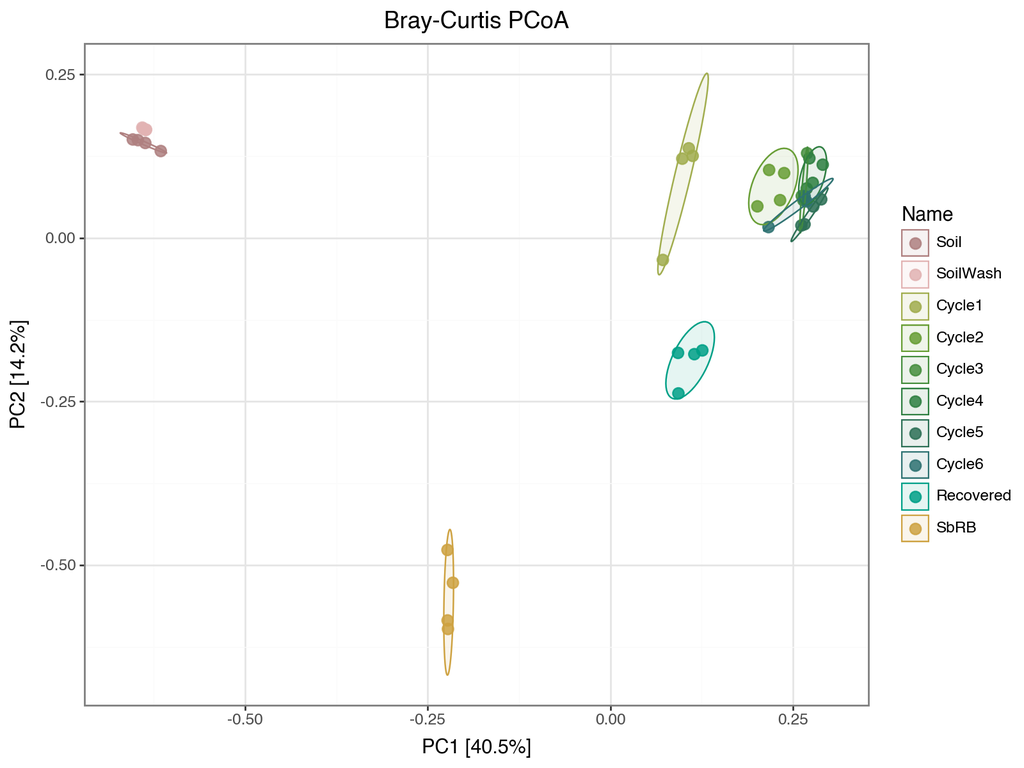

```python
from plotnine import geom_point, scale_color_manual, scale_fill_manual, stat_ellipse

meta_df = ps2_rooted.sample_data.to_frame()


def pcoa_plot(result, ps_obj, title):
    """PCoA scatter with 80% t-ellipses per group."""
    scores = result.samples.copy().join(ps_obj.sample_data.to_frame())
    pct = result.proportion_explained
    scores["Name"] = pd.Categorical(scores["Name"], categories=name_order, ordered=True)
    return (
        ggplot(scores, aes(x="PC1", y="PC2", color="Name", fill="Name"))
        + geom_point(size=3, alpha=0.85)
        + stat_ellipse(aes(group="Name"), type="t", level=0.80,
                       geom="polygon", alpha=0.10)
        + scale_color_manual(values=name_colors)
        + scale_fill_manual(values=name_colors)
        + theme_bw()
        + theme(figure_size=(8, 6))
        + ggtitle(title)
        + labs(
            x=f"PC1 [{pct.iloc[0]*100:.1f}%]",
            y=f"PC2 [{pct.iloc[1]*100:.1f}%]",
        )
    )


# R: ord = ordinate(ps2.css.prop, method="PCoA", distance="bray")
#    plot_ordination(ps2.css.prop, ord, color="Name") + geom_point(size=5)
pcoa_plot(pcoa_bray, ps2_rel_count, "Bray-Curtis PCoA")
```

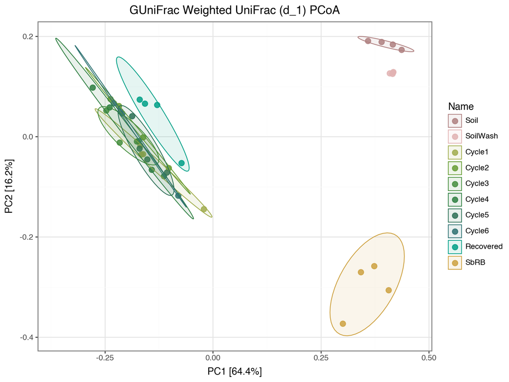

```python
pcoa_plot(pcoa_d1, ps2_rooted, "GUniFrac Weighted UniFrac (d_1) PCoA")
```

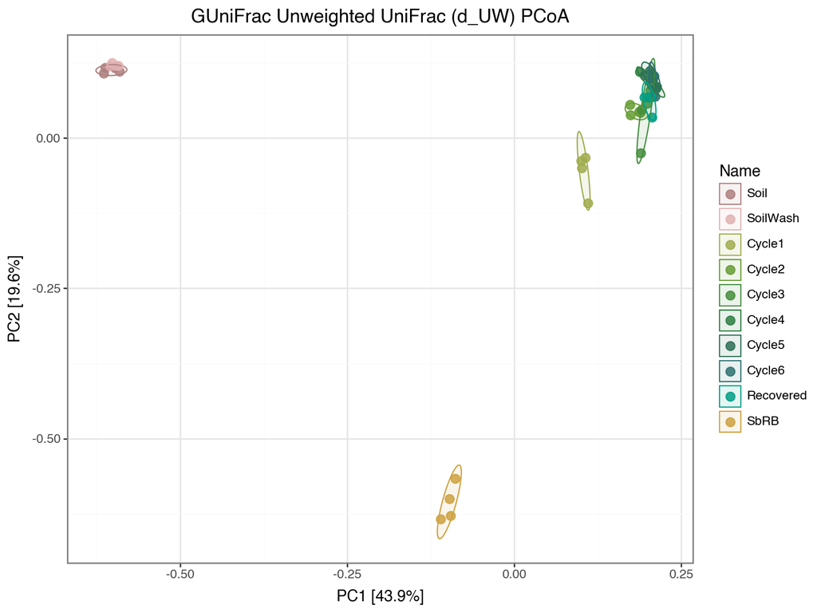

```python
pcoa_plot(pcoa_du, ps2_rooted, "GUniFrac Unweighted UniFrac (d_UW) PCoA")
```

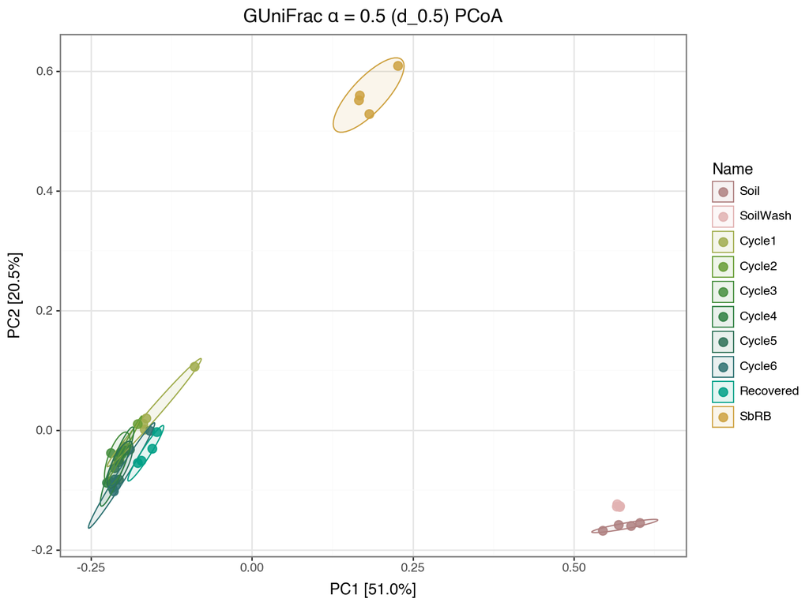

```python
pcoa_plot(pcoa_d05, ps2_rooted, "GUniFrac α = 0.5 (d_0.5) PCoA")
```

### 8. PERMANOVA — Does Community Structure Differ Across Groups?

PERMANOVA (`adonis` in R's vegan) partitions variance in a distance matrix by group. We test whether microbial community composition differs significantly across the 10 sample groups (Soil, SoilWash, Cycle1–6, Recovered, SbRB).

| R call | Python equivalent |
| --- | --- |
| `adonis(as.dist(d5) ~ Name, data=sample_data(ps2))` | `skbio.stats.distance.permanova(dm, groups)` |

```python
# R: adonis(as.dist(d5) ~ Name, data=sample_data(ps2), permutations=999)
print("PERMANOVA results (999 permutations) — H₀: no community composition difference across groups\n")
for label, dm in [
    ("Bray-Curtis",               bray),
    ("Weighted UniFrac (d_1)",    d1),
    ("Unweighted UniFrac (d_UW)", du),
    ("GUniFrac α=0.5 (d_0.5)",   d05),
]:
    res = permanova(dm, ps2, "Name", permutations=999)
    sig = "***" if res["p-value"] < 0.001 else "**" if res["p-value"] < 0.01 else "*" if res["p-value"] < 0.05 else "ns"
    print(f"{label:<35} pseudo-F = {res['test statistic']:7.3f}   p = {res['p-value']:.3f}  {sig}")
```

```
PERMANOVA results (999 permutations) — H₀: no community composition difference across groups

Bray-Curtis                         pseudo-F =  17.055   p = 0.001  **
Weighted UniFrac (d_1)              pseudo-F =  26.880   p = 0.001  **
Unweighted UniFrac (d_UW)           pseudo-F =  14.323   p = 0.001  **
GUniFrac α=0.5 (d_0.5)              pseudo-F =  25.876   p = 0.001  **
```

### 9. Sample Similarity — Bray-Curtis Distance Heatmap

A clustermap of the pairwise Bray-Curtis dissimilarity matrix reveals which groups cluster together. R uses `ComplexHeatmap::Heatmap`; we use `seaborn.clustermap` with hierarchical clustering and group-colored annotation bars.

| R call | Python equivalent |
| --- | --- |
| `phyloseq::distance(ps2.css.prop, method="bray")` | `pyloseq.distance(ps2_rel_count, method="bray")` |
| `ComplexHeatmap::Heatmap(bray, column_km=3, row_km=3)` | `seaborn.clustermap(bray_df)` |

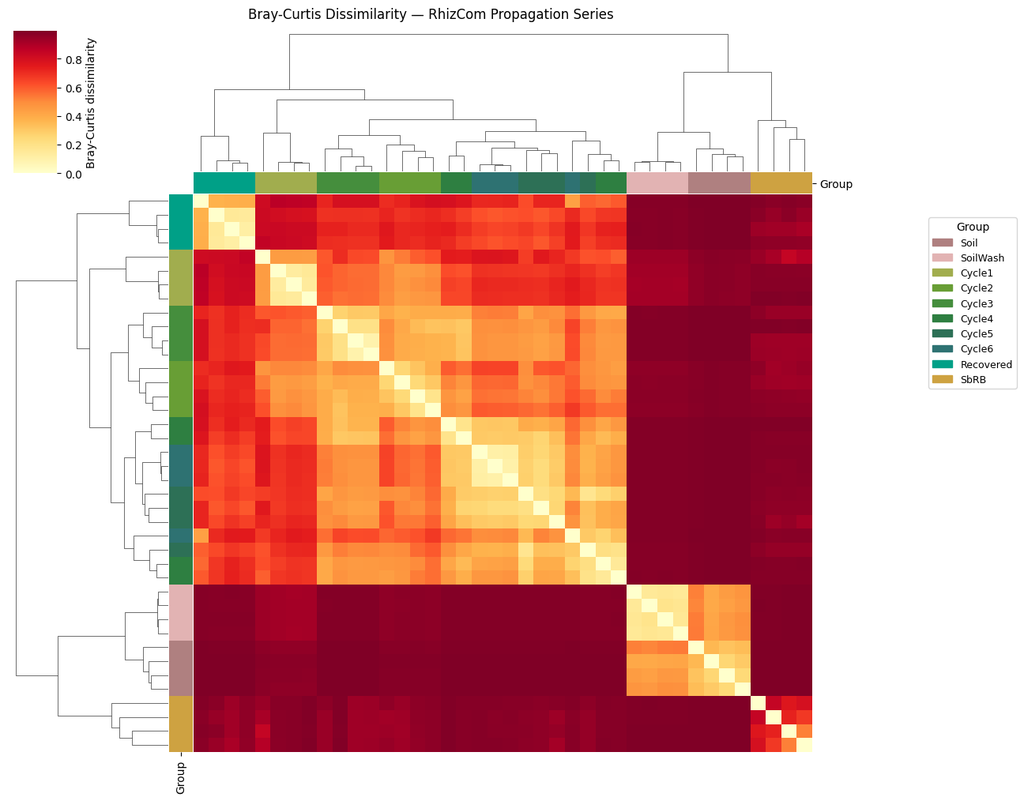

```python
# R: bray = as.data.frame(as.matrix(phyloseq::distance(ps2.css.prop, method="bray")))
#    Heatmap(bray, ...)
bray_mat = pd.DataFrame(bray.data, index=bray.ids, columns=bray.ids)

# Annotation colors: one color per sample based on group membership
row_colors = pd.Series(
    {s: name_colors.get(meta_df.loc[s, "Name"], "grey") for s in bray_mat.index},
    name="Group",
)

g = sns.clustermap(
    bray_mat,
    row_cluster=True,
    col_cluster=True,
    row_colors=row_colors,
    col_colors=row_colors,
    cmap="YlOrRd",
    figsize=(11, 10),
    xticklabels=False,
    yticklabels=False,
    cbar_kws={"label": "Bray-Curtis dissimilarity"},
)
g.fig.suptitle("Bray-Curtis Dissimilarity — RhizCom Propagation Series", y=1.01)

# Group legend
patches = [mpatches.Patch(color=name_colors[n], label=n)
           for n in name_order if n in name_colors]
g.fig.legend(handles=patches, title="Group",
             bbox_to_anchor=(1.18, 0.75), loc="upper right", fontsize=9)
plt.show()
```

### 10. ASV Source Tracking — Cycle6 Origins

For each ASV present in **Cycle6** (the final propagation cycle), we ask: can its presence be traced to another group in the experiment? Three categories are assigned:

| Category | Criterion |
| --- | --- |
| Traced: SoilWash or SbRB | ASV present in SoilWash > 0 **or** SbRB > 0 |
| Traced: earlier cycles / Soil | Not in SoilWash/SbRB, but mean abundance across Cycle1–5 > 0 or Soil > 0 |
| Not tracked | Absent from all other groups |

Replicates are pooled (summed) per group before the comparison. This reproduces the doughnut chart from the R script (section 13.2).

| R call | Python equivalent |
| --- | --- |
| `merge_samples(ps2.css.merg, "Name", fun=mean)` | Group-wise sum on OTU table |
| `filter(ps2.css.merg.df, Cycle6 > 0 & SoilWash > 0)` | Boolean indexing on grouped DataFrame |
| `ggplot(...) + geom_rect() + coord_polar(theta="y")` | `matplotlib.pyplot.pie` with donut styling |

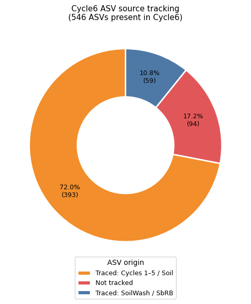

```
Cycle6 ASV source tracking:
  Traced: Cycles 1–5 / Soil: 393 ASVs (72.0%)
  Not tracked: 94 ASVs (17.2%)
  Traced: SoilWash / SbRB: 59 ASVs (10.8%)
  Total Cycle6 ASVs: 546
```

```python
# R: ps2.css.merg = merge_samples(ps2.css, "Name", fun=mean)
# merge_samples sums OTU abundances per group; reindex columns to match name_order
ps2_merged = merge_samples(ps2, "Name")
group_df = ps2_merged.otu_table.to_dataframe()[name_order]  # taxa × groups in defined order

# R: rhizcom = subset_samples(ps2.css.merg, Name=="Cycle6")
#    rhizcomASVs = taxa_names(prune_taxa(taxa_sums > 0, rhizcom))
cycle6_asvs = group_df[group_df["Cycle6"] > 0].index.tolist()
sub = group_df.loc[cycle6_asvs]

# Mean abundance across Cycles 1–5
cycle_cols = [f"Cycle{i}" for i in range(1, 6)]
cycles15_mean = sub[cycle_cols].mean(axis=1)


def classify_asv(row):
    if row["SoilWash"] > 0 or row["SbRB"] > 0:
        return "Traced: SoilWash / SbRB"
    elif cycles15_mean[row.name] > 0 or row["Soil"] > 0:
        return "Traced: Cycles 1–5 / Soil"
    else:
        return "Not tracked"


categories = sub.apply(classify_asv, axis=1)
counts = categories.value_counts()

cat_colors = {
    "Traced: SoilWash / SbRB":  "#4e79a7",
    "Traced: Cycles 1–5 / Soil": "#f28e2b",
    "Not tracked":               "#e15759",
}
labels = counts.index.tolist()
sizes  = counts.values
colors = [cat_colors.get(l, "grey") for l in labels]

fig, ax = plt.subplots(figsize=(7, 6))
wedges, _, autotexts = ax.pie(
    sizes, labels=None, colors=colors,
    autopct=lambda p: f"{p:.1f}%\n({int(round(p / 100 * sum(sizes)))})",
    startangle=90, pctdistance=0.75,
    wedgeprops={"width": 0.5, "edgecolor": "white", "linewidth": 2},
)
for t in autotexts:
    t.set_fontsize(9)
ax.legend(wedges, labels, title="ASV origin",
          loc="lower center", bbox_to_anchor=(0.5, -0.15), ncol=1, fontsize=9)
ax.set_title(
    f"Cycle6 ASV source tracking\n({len(cycle6_asvs)} ASVs present in Cycle6)",
    fontsize=11,
)
plt.tight_layout()
plt.show()

print("\nCycle6 ASV source tracking:")
for cat in labels:
    print(f"  {cat}: {counts[cat]} ASVs ({counts[cat] / len(cycle6_asvs) * 100:.1f}%)")
print(f"  Total Cycle6 ASVs: {len(cycle6_asvs)}")
```